# EP03 Logistic Regression Practical 3

Here we will examine the Vaccination data set (from Mead (1988) the Design of experiments: statistical principles for practical application). In the study from which the data set was taken a vaccination study was carried out using different vaccination methods. Additionally there are different batches of vaccine and different areas from which the subjects were sampled. The data set is loaded and named `vaccination`. All subjects were tested if the vaccination succeeded (a positive outcome) or not (a negative outcome).

### Question 1

First plot the data set. What is the number of subjects that are tested, and how many tested positive and negative? Created a variable `Nneg` that contains the number of patients that tested negative.

```r
vaccination$Nneg <- with(vaccination, Ntested-Npos)
vaccination
```

```
##             Area            Method  NeedleType Vaccine.batch Ntested Npos Nneg
## 1  Staffordshire Multiple puncture       Fixed             1     228  223    5
## 2  Staffordshire Multiple puncture  Detachable             1     221  210   11
## 3  Staffordshire Multiple puncture       Fixed             2     230  218   12
## 4  Staffordshire       Intradermal lntradermal             4     240  238    2
## 5        Cardiff Multiple puncture       Fixed             2     221  181   40
## 6        Cardiff Multiple puncture  Detachable             2     213  158   55
## 7        Cardiff Multiple puncture       Fixed             3     200  160   40
## 8        Cardiff       Intradermal Intradermal             4     214  186   28
## 9      Sheffield Multiple puncture       Fixed             1     223  198   25
## 10     Sheffield Multiple puncture  Detachable             3     228  189   39
## 11     Sheffield Multiple puncture       Fixed             3     216  177   39
## 12     Sheffield       Intradermal lntradermal             4     224  206   18
```

```r
sum(vaccination$Ntested)
```

```
## [1] 2658
```

```r
sum(vaccination$Npos)
```

```
## [1] 2344
```

```r
sum(vaccination$Nneg)
```

```
## [1] 314
```

### Question 2

Estimate a logistic regression model using only the `Method` as predictor. Keep the data in aggregated form. Call the model `glm1`. Also compute odds ratios and their confidence intervals.

```r
glm1 <- glm(cbind(Npos, Nneg) ~ Method, data=vaccination, family='binomial')
exp(coef(glm1))
```

```
##             (Intercept) MethodMultiple puncture
##              13.1250000               0.4909416
```

```r
exp(confint(glm1))
```

```
##                             2.5 %     97.5 %
## (Intercept)             9.9020217 17.8321185
## MethodMultiple puncture 0.3524721  0.6702281
```

```r
glm0 <- glm(cbind(Npos, Nneg) ~ 1, data=vaccination, family='binomial')
anova(glm0, glm1,test='LRT')
```

```
## Analysis of Deviance Table
##
## Model 1: cbind(Npos, Nneg) ~ 1
## Model 2: cbind(Npos, Nneg) ~ Method
##   Resid. Df Resid. Dev Df Deviance  Pr(>Chi)
## 1        11     164.82
## 2        10     143.28  1   21.538 3.469e-06 ***
## ---
## Signif. codes:  0 '***' 0.001 '**' 0.01 '*' 0.05 '.' 0.1 ' ' 1
```

### Question 3

Now correct for `Area` and `Vaccine.batch`. Call the model `glm2`. Again compute odds ratios and their confidence intervals. Perform a likelihood ratio test on the effect of the method.

```r
glm2 <- glm(cbind(Npos, Nneg) ~ Method + Area + Vaccine.batch,
            data=vaccination, family='binomial')
exp(coef(glm2))
```

```
##             (Intercept) MethodMultiple puncture           AreaSheffield
##              13.8677737               0.3703338               1.5322581
##       AreaStaffordshire           Vaccine.batch
##               6.2645638               0.8580982
```

```r
exp(confint(glm2))
```

```
##                             2.5 %     97.5 %
## (Intercept)             6.0184493 32.4351720
## MethodMultiple puncture 0.2313256  0.5878634
## AreaSheffield           1.1841616  1.9875118
## AreaStaffordshire       4.1258228  9.7923396
## Vaccine.batch           0.7067944  1.0373529
```

```r
glm0 <- glm(cbind(Npos, Nneg) ~ Area + Vaccine.batch, data=vaccination, family='binomial')
anova(glm0, glm2,test='LRT')
```

```
## Analysis of Deviance Table
##
## Model 1: cbind(Npos, Nneg) ~ Area + Vaccine.batch
## Model 2: cbind(Npos, Nneg) ~ Method + Area + Vaccine.batch
##   Resid. Df Resid. Dev Df Deviance Pr(>Chi)
## 1         8     30.408
## 2         7     12.426  1   17.982 2.23e-05 ***
## ---
## Signif. codes:  0 '***' 0.001 '**' 0.01 '*' 0.05 '.' 0.1 ' ' 1
```

### Question 4

Now perform a deviance test to check the overall goodness-of-fit of `glm2`.

```r
glm_sat <- glm(cbind(Npos, Nneg) ~ Method*Area*Vaccine.batch,
            data=vaccination, family='binomial')

anova(glm2, glm_sat, test='LRT')
```

```
## Analysis of Deviance Table
##
## Model 1: cbind(Npos, Nneg) ~ Method + Area + Vaccine.batch
## Model 2: cbind(Npos, Nneg) ~ Method * Area * Vaccine.batch
##   Resid. Df Resid. Dev Df Deviance Pr(>Chi)
## 1         7    12.4264
## 2         3     6.4489  4   5.9775   0.2008
```

```r
# or
n_coef_sat <- length(coef(glm_sat)[!is.na(coef(glm_sat))])
n_coef_2 <-length(coef(glm2)[!is.na(coef(glm2))])

pchisq(as.vector(-2*(logLik(glm2)- logLik(glm_sat))), n_coef_sat- n_coef_2,lower.tail = FALSE )
```

```
## [1] 0.2008333
```

### Question 5

Use the function `influencePlot` to check if there are unusual observations. This function is defined in the `car` package which we have already loaded.

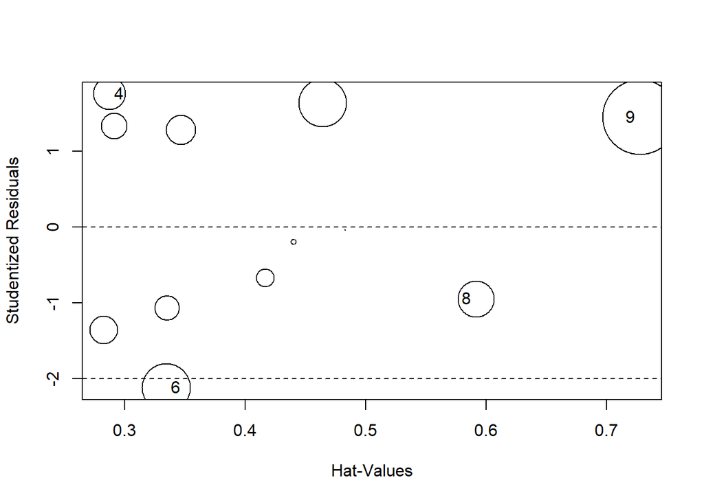

```
##      StudRes       Hat     CookD
## 4  1.7598061 0.2872142 0.2067981
## 6 -2.1214344 0.3341245 0.4675385
## 8 -0.9508039 0.5916483 0.2653567
## 9  1.4488760 0.7276056 1.1094269
```

```r
influencePlot(glm2)
```